# Work, governance, and well-being

Research Cluster 2

Cluster 2 brings together research on **work, governance, and well-being**. Two communities examine different stages of working life. Personnel selection research asks how employers assess applicants, how applicants manage the impressions they make, and whether interview ratings predict job performance. The workplace stress and leadership community examines how supervision, job demands, and social support relate to burnout, safety, job satisfaction, and turnover.

The corporate governance community examines who oversees firms, what firms disclose, and how investors assess their performance. The gender and inequality community looks at organizations and labour markets from the perspective of who gains access to work and how earnings and opportunities vary across social groups. Its research on identity, religion, and belonging extends that inquiry beyond employment. Environmental governance takes questions about authority and participation into another setting. Here, the focus is on how institutions and communities share decisions about resources, protect ecosystems, and respond to climate risks that can affect livelihoods unevenly.

The physical activity community shares the workplace community’s interest in health and the conditions that shape it. It examines how common physical activity is, how it fits into adults’ daily routines, and what limits participation. Work on classifying activities and measuring how people spend their time helps researchers compare activity patterns across populations.

Three forms of evidence below show what the keyword communities are about and how they relate to one another.

**Interactive keyword network.** Each point represents a keyword, and a line connects two keywords that appear together in one or more publications. The full network shows how keyword communities relate to one another. Select a community from the dropdown to see which terms group together and which connect to terms in other communities. Connections within a community show which subjects, methods, or concepts appear together. Connections across communities show where their vocabularies overlap.

**Community word clouds.** Each cloud shows the vocabulary of one community. Larger words have higher within-community PageRank. This measure reflects both the strength of a keyword’s connections and how well connected its neighbours are. Larger words therefore show which terms are most prominent in the community’s pattern of connections. Smaller words can give those terms context by identifying particular subjects, settings, or methods.

**Affiliated publications.** Each publication has a set of membership values, one for each community. A value of 1 means that all of the publication’s keyword-based membership is assigned to that community. When membership is distributed across communities, the values show how that affiliation is shared. For example, values of 0.7 and 0.3 indicate that the publication’s keywords align more strongly with the first community while also connecting it to the second. The publication lists show how the themes visible in the keyword network are represented in the institution’s research.

[interactive chart not shown]

## Community 1: Workplace stress, leadership, and employee well-being

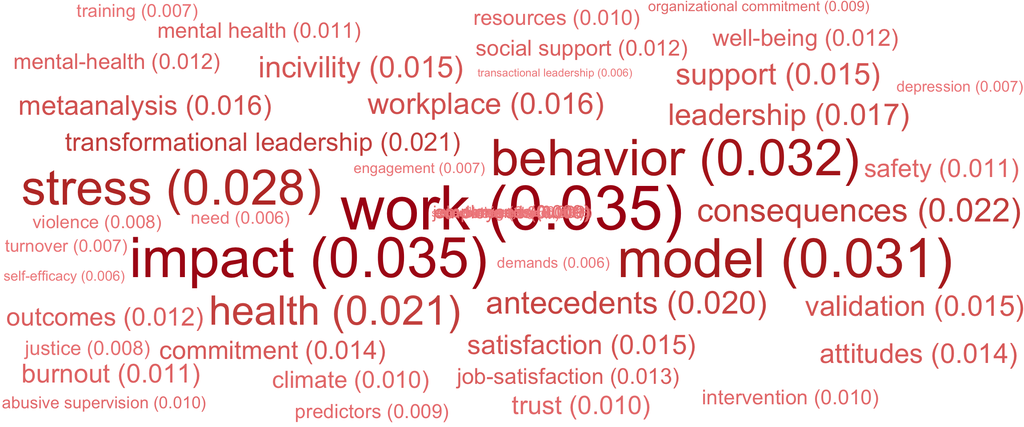

Community 1 of Cluster 2 brings together research on how working conditions and relationships shape employee behaviour, health, and well-being. One strand concerns leadership and supervision. Its vocabulary ranges from transformational leadership and social support to abusive supervision, incivility, and workplace aggression. These terms point to questions about how employees experience the conduct of supervisors and colleagues, and how those experiences relate to trust, job satisfaction, engagement, and organizational commitment.

A second strand concerns the demands of work and the resources employees can draw on. “Job demands,” “strain,” “burnout,” and “psychological distress” sit alongside “social support,” “resources,” and “self-efficacy.” The health focus extends to physical safety through terms such as “safety climate,” “injuries,” and “accidents.” “Training,” “intervention,” and “prevention” point to research on how organizations can respond to these problems. Nurses and young workers are two groups represented in the keyword network.

The community also includes terms that describe how these questions are studied. “Antecedents,” “predictors,” and “consequences” point to research on what precedes workplace experiences and what follows them. “Validation,” “questionnaire,” and “scale development” point to work on how researchers measure those experiences and their outcomes.

## Community 2: Gender, identity, and social inequality

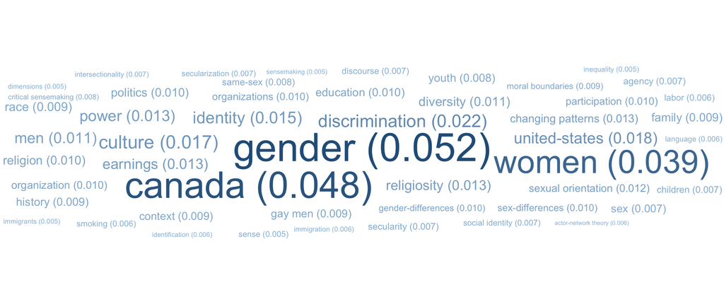

This community in Cluster 2 examines how gender and other social distinctions shape people’s opportunities, experiences, and sense of belonging. “Gender” (0.052), “Canada” (0.048), and “women” (0.039) have the highest within-community PageRank, followed by “discrimination” (0.022). Canada is the most prominent setting named in the network, with the United States and Quebec also represented. Terms such as “earnings,” “wage gap,” and “employment” point to research on how economic outcomes vary across groups. “Sexual orientation,” “gay men,” “lesbians,” and “same-sex” give sexuality a visible place in the community, while “race,” “immigration,” and “intersectionality” point to questions about how different social distinctions overlap.

The community also examines how people define who belongs. “Religiosity,” “secularity,” and “moral boundaries” point to research on how beliefs and practices mark distinctions between groups. “Critical sensemaking,” “discourse,” and “social identity” suggest an interest in how people interpret those distinctions and give them meaning in organizations and everyday life.

The connection to Community 1 is clearest in research on work and fair treatment. Community 1 asks how supervision, support, and organizational justice relate to employees’ health and working lives. This community asks how access to employment, earnings, and participation differ across social groups, and how those distinctions take shape in settings beyond work.

## Community 3: Corporate governance, disclosure, and firm performance

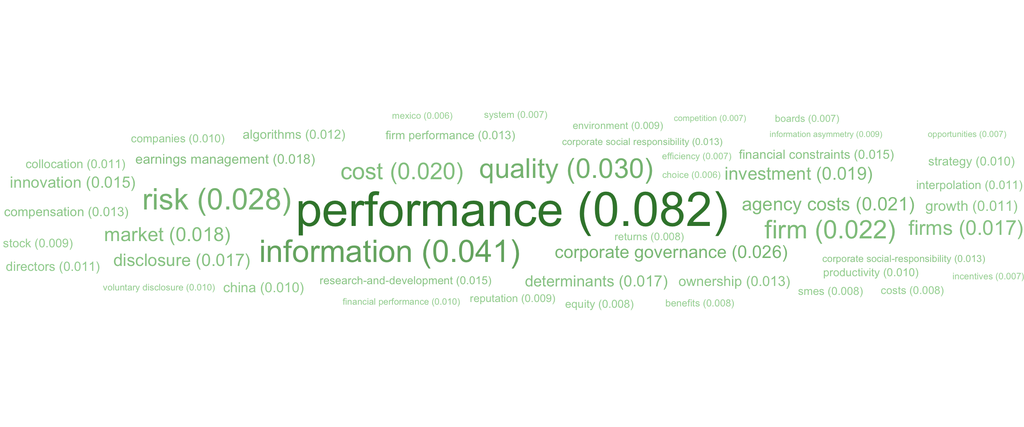

This community in Cluster 2 examines how firms are governed, what they report to outsiders, and how these practices relate to performance. “Performance” (0.082) and “information” (0.041) lead the within-community PageRank ranking. Keywords such as “boards,” “ownership,” “compensation,” and “agency costs” point to questions about who oversees managers and what happens when managers and owners have different interests. “Voluntary disclosure,” “earnings management,” and “information asymmetry” turn attention to what investors can learn from company reports and how they assess a firm’s performance and risk.

The community also includes research on the decisions that shape performance. “Financial constraints,” “investment,” and “research-and-development” point to questions about what firms can afford to invest in and how those choices relate to innovation and growth. “Corporate social responsibility” and “reputation” extend the inquiry to how firms are judged for their conduct as well as their financial results.

The connection to Community 1 runs through how organizations are managed. Community 1 looks at supervision, support, and fair treatment from the employee’s perspective. This community looks at oversight and incentives at the level of the firm. It also has a point of contact with the gender and inequality community through pay. Here, compensation appears as a question about incentives and governance, while the gender community examines how earnings differ across social groups.

## Community 4: Environmental governance, conservation, and climate adaptation

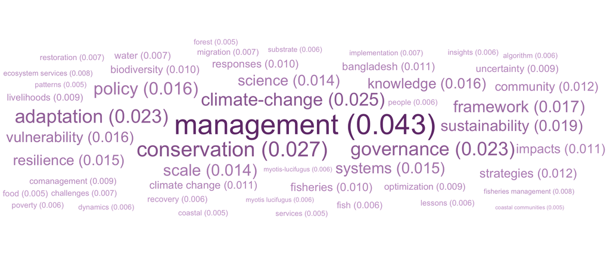

## Community 5: Personnel selection and applicant assessment

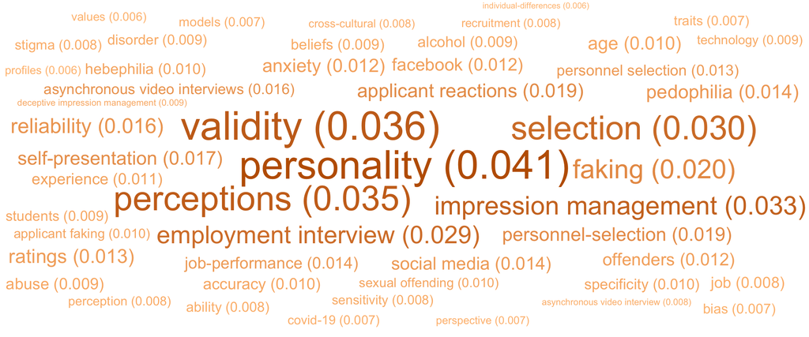

This community in Cluster 2 examines how employers assess job applicants and how applicants shape the impressions they make. “Personality” (0.041), “validity” (0.036), and “perceptions” (0.035) have the highest within-community PageRank. The interview vocabulary gives those terms a setting. On the employer’s side, “ratings,” “reliability,” and “job performance” point to questions about how consistently interviewers assess applicants and how well their ratings predict later performance. On the applicant’s side, “self-presentation,” “impression management,” and “faking” point to how people present their qualifications. “Applicant reactions” and “asynchronous video interviews” extend the inquiry to how applicants experience formats in which they record answers without a live interviewer.

The connection to Community 1 is through two stages of working life. This community examines how people are assessed for entry into a workplace. Community 1 examines how supervision, support, and working conditions relate to employee health and well-being once people are at work. There is also a point of contact with the gender and inequality community. “Bias” raises questions about how hiring judgments are made, while the gender and inequality community examines how access to employment and earnings vary across social groups.

A separate strand concerns sexual offending and responses to it, as indicated by “sexual offending,” “offenders,” “corrections,” and “stigma.”

## Community 6: Physical activity in everyday life

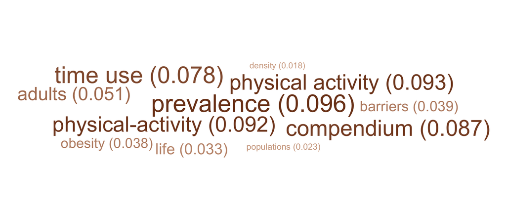

This community in Cluster 2 examines how physically active people are, how activity fits into daily life, and what limits participation. “Prevalence” (0.096) leads the within-community PageRank ranking, followed by two variants of “physical activity” (both about 0.093). “Compendium” (0.087) and “time use” (0.078) point to the work of classifying activities and measuring how people spend their time. “Adults” and “populations” give that measurement a population focus, while “barriers” points to circumstances that can make it harder to be active. “Obesity” places physical activity in a broader public health context.

The closest connection is to Community 1’s research on employee health and well-being. Both examine how everyday conditions relate to health. Community 1 focuses on conditions within workplaces, such as job demands and social support. This community asks how physical activity fits into people’s routines and what helps explain differences in participation across populations.

## Most cited publications by community

Select one of the communities above to populate the table. The table shows up to five publications per selected research community, arranged by highest Total Citation count within the research community under consideration. Under Membership vector the column headers indicate abbreviated research community labels. Each row sum totals 1.0. Values of 1 indicate maximal research community affiliation; distributed values indicate multithematic papers whose affiliation reaches into more than one research community (Aria et al. 2026; Aria and Cuccurullo 2026). TCpY = Total Citations per Year.

Community:

| Publication title | Year | TC | TCpY | Membership vector Wor. | Membership vector Gen. | Membership vector Fir. | Membership vector Env. | Membership vector Per. | Membership vector Phy. |
| --- | --- | --- | --- | --- | --- | --- | --- | --- | --- |
| Development and Test of a Model Linking Safety-Specific Transformational Leadership and Occupational Safety | 2002 | 707 | 28.3 | 0.8 | 0.0 | 0.2 | 0.0 | 0.1 | 0.0 |
| Transformational Leadership and Psychological Well-Being: The Mediating Role of Meaningful Work | 2007 | 671 | 33.5 | 0.5 | 0.0 | 0.0 | 0.0 | 0.5 | 0.0 |
| Workplace Empowerment, Incivility, and Burnout: Impact on Staff Nurse Recruitment and Retention Outcomes | 2009 | 401 | 22.3 | 0.9 | 0.0 | 0.0 | 0.1 | 0.1 | 0.0 |
| The Impact of Civility Interventions on Employee Social Behavior, Distress, and Attitudes | 2011 | 366 | 22.9 | 1.0 | 0.0 | 0.0 | 0.0 | 0.0 | 0.0 |
| Corporate Social Responsibilities, Consumer Trust and Corporate Reputation: South Korean Consumers' Perspectives | 2014 | 361 | 27.8 | 0.7 | 0.1 | 0.1 | 0.1 | 0.0 | 0.0 |
| a Three-Factor Model of Social Identity | 2004 | 938 | 40.8 | 0.0 | 0.8 | 0.0 | 0.2 | 0.0 | 0.0 |
| Preferred Interpersonal Distances: a Global Comparison | 2017 | 312 | 31.2 | 0.0 | 0.7 | 0.0 | 0.3 | 0.0 | 0.0 |
| Isolated Environmental Cues and Product Efficacy Penalties: The Color Green and Eco-Labels | 2017 | 158 | 15.8 | 0.0 | 0.5 | 0.0 | 0.2 | 0.2 | 0.0 |
| Community-Based Monitoring Frameworks: Increasing the Effectiveness of Environmental Stewardship | 2008 | 110 | 5.8 | 0.0 | 0.6 | 0.0 | 0.4 | 0.0 | 0.0 |
| when "Don't Worry" Communicates Fear: Children's Perceptions of Parental Reassurance and Distraction During a Painful Medical Procedure | 2010 | 103 | 6.1 | 0.3 | 0.6 | 0.0 | 0.1 | 0.0 | 0.0 |
| The Relationship Between Firm Investment and Financial Status | 1999 | 763 | 27.2 | 0.0 | 0.0 | 1.0 | 0.0 | 0.0 | 0.0 |
| Corporate Social Responsibility and Credit Ratings | 2013 | 549 | 39.2 | 0.0 | 0.0 | 0.8 | 0.2 | 0.0 | 0.0 |
| The Primordial Stakeholder: Advancing the Conceptual Consideration of Stakeholder Status for the Natural Environment | 2004 | 303 | 13.2 | 0.0 | 0.3 | 0.6 | 0.2 | 0.0 | 0.0 |
| Basic Instrumentation for Hall a at Jefferson Lab | 2004 | 246 | 10.7 | 0.0 | 0.0 | 0.5 | 0.5 | 0.0 | 0.0 |
| Multiple Large Shareholders, Control Contests, and Implied Cost of Equity | 2008 | 244 | 12.8 | 0.0 | 0.0 | 1.0 | 0.0 | 0.0 | 0.0 |
| Adaptive Co-Management for Social-Ecological Complexity | 2009 | 1041 | 57.8 | 0.0 | 0.0 | 0.0 | 1.0 | 0.0 | 0.0 |
| a Review of Citizen Science and Community-Based Environmental Monitoring: Issues and Opportunities | 2011 | 957 | 59.8 | 0.0 | 0.0 | 0.0 | 1.0 | 0.0 | 0.0 |
| Plant Functional Trait Change Across a Warming Tundra Biome | 2018 | 594 | 66.0 | 0.0 | 0.0 | 0.0 | 1.0 | 0.0 | 0.0 |
| Key Principles of Marine Ecosystem-Based Management | 2015 | 408 | 34.0 | 0.0 | 0.0 | 0.0 | 1.0 | 0.0 | 0.0 |
| Technico-Economic Analysis of Off Grid Solar Pv/Fuel Cell Energy System for Residential Community in Desert Region | 2020 | 271 | 38.7 | 0.2 | 0.0 | 0.0 | 0.8 | 0.0 | 0.0 |
| Why it Pays to Get Inside the Head of your Opponent - the Differential Effects of Perspective Taking and Empathy in Negotiations | 2008 | 528 | 27.8 | 0.3 | 0.0 | 0.0 | 0.0 | 0.7 | 0.0 |
| using an Ability-Based Measure of Emotional Intelligence to Predict Individual Performance, Group Performance, and Group Citizenship Behaviours | 2004 | 270 | 11.7 | 0.0 | 0.3 | 0.2 | 0.0 | 0.5 | 0.0 |
| Assessing the Predictive Validity of Emotional Intelligence | 2000 | 189 | 7.0 | 0.2 | 0.2 | 0.0 | 0.0 | 0.6 | 0.0 |
| Soft Clustering - Fuzzy and Rough Approaches and their Extensions and Derivatives | 2013 | 156 | 11.1 | 0.0 | 0.0 | 0.0 | 0.0 | 1.0 | 0.0 |
| "Now We Understand What Community Really Means": Reconceptualizing the Role of Sense of Place in the Disaster Recovery Process | 2015 | 119 | 9.9 | 0.0 | 0.0 | 0.0 | 0.3 | 0.7 | 0.0 |
| Weather Impacts on Leisure Activities in Halifax, Nova Scotia | 2011 | 77 | 4.8 | 0.0 | 0.1 | 0.3 | 0.0 | 0.0 | 0.7 |
| Time and Money: a New Look at Poverty and the Barriers to Physical Activity in Canada | 2010 | 72 | 4.2 | 0.1 | 0.1 | 0.1 | 0.1 | 0.0 | 0.6 |
| The Impact of Spinal Cord Injury on Men's Time Use | 1999 | 49 | 1.8 | 0.4 | 0.0 | 0.1 | 0.0 | 0.0 | 0.5 |
| Quantitative Trait Loci Underlying the Development of Seed Composition in Soybean (Glycine Max L. Merr.) | 2007 | 23 | 1.1 | 0.5 | 0.0 | 0.0 | 0.0 | 0.0 | 0.5 |
| Measuring Active Living in Canada: a Time-Use Perspective | 2011 | 20 | 1.2 | 0.2 | 0.1 | 0.0 | 0.0 | 0.0 | 0.7 |

## References

Aria, Massimo, and Corrado Cuccurullo. 2026. *Science Mapping Analysis: A Primer with Biblioshiny*. Mailand: McGraw-Hill Education.

Aria, Massimo, Luca D’Aniello, Michelangelo Misuraca, and Maria Spano. 2026. “Rethinking Thematic Evolution in Science Mapping:an Integrated Framework for Longitudinal Analysis.” *Journal of Informetrics* 20 (4): 101877. https://doi.org/10.1016/j.joi.2026.101877.